# Project: Wrangling and Analyzing Data

## Gathering Data

```python
#importing the libraries into the juypter notebook.
import pandas as pd
import requests
import numpy as np
```

```python
#Loading the twitter archive enhanced into notebook.
df1_archive_enhanced=pd.read_csv('twitter-archive-enhanced.csv')
```

```python
#the frist 10 rows of twitter_archive _enhanced
df1_archive_enhanced.head()
```

|  | tweet_id | in_reply_to_status_id | in_reply_to_user_id | timestamp | source | text | retweeted_status_id | retweeted_status_user_id | retweeted_status_timestamp | expanded_urls | rating_numerator | rating_denominator | name | doggo | floofer | pupper | puppo |
| --- | --- | --- | --- | --- | --- | --- | --- | --- | --- | --- | --- | --- | --- | --- | --- | --- | --- |
| 0 | 892420643555336193 | NaN | NaN | 2017-08-01 16:23:56 +0000 | <a href="http://twitter.com/download/iphone" r... | This is Phineas. He's a mystical boy. Only eve... | NaN | NaN | NaN | https://twitter.com/dog_rates/status/892420643... | 13 | 10 | Phineas | None | None | None | None |
| 1 | 892177421306343426 | NaN | NaN | 2017-08-01 00:17:27 +0000 | <a href="http://twitter.com/download/iphone" r... | This is Tilly. She's just checking pup on you.... | NaN | NaN | NaN | https://twitter.com/dog_rates/status/892177421... | 13 | 10 | Tilly | None | None | None | None |
| 2 | 891815181378084864 | NaN | NaN | 2017-07-31 00:18:03 +0000 | <a href="http://twitter.com/download/iphone" r... | This is Archie. He is a rare Norwegian Pouncin... | NaN | NaN | NaN | https://twitter.com/dog_rates/status/891815181... | 12 | 10 | Archie | None | None | None | None |
| 3 | 891689557279858688 | NaN | NaN | 2017-07-30 15:58:51 +0000 | <a href="http://twitter.com/download/iphone" r... | This is Darla. She commenced a snooze mid meal... | NaN | NaN | NaN | https://twitter.com/dog_rates/status/891689557... | 13 | 10 | Darla | None | None | None | None |
| 4 | 891327558926688256 | NaN | NaN | 2017-07-29 16:00:24 +0000 | <a href="http://twitter.com/download/iphone" r... | This is Franklin. He would like you to stop ca... | NaN | NaN | NaN | https://twitter.com/dog_rates/status/891327558... | 12 | 10 | Franklin | None | None | None | None |

```python
#programmatically downloading the image-prediction.tsv using request given url into notebook
url = "https://d17h27t6h515a5.cloudfront.net/topher/2017/August/599fd2ad_image-predictions/image-predictions.tsv"
response = requests.get(url)
with open('image-predictions.tsv' ,mode ='wb') as file:
    file.write(response.content)
```

```python
#loading the image prediction
df_image_prediction=pd.read_csv('image-predictions.tsv', sep='\t')
```

```python
#the first 3 rows of df_image_prediction
df_image_prediction.head(3)
```

|  | tweet_id | jpg_url | img_num | p1 | p1_conf | p1_dog | p2 | p2_conf | p2_dog | p3 | p3_conf | p3_dog |
| --- | --- | --- | --- | --- | --- | --- | --- | --- | --- | --- | --- | --- |
| 0 | 666020888022790149 | https://pbs.twimg.com/media/CT4udn0WwAA0aMy.jpg | 1 | Welsh_springer_spaniel | 0.465074 | True | collie | 0.156665 | True | Shetland_sheepdog | 0.061428 | True |
| 1 | 666029285002620928 | https://pbs.twimg.com/media/CT42GRgUYAA5iDo.jpg | 1 | redbone | 0.506826 | True | miniature_pinscher | 0.074192 | True | Rhodesian_ridgeback | 0.072010 | True |
| 2 | 666033412701032449 | https://pbs.twimg.com/media/CT4521TWwAEvMyu.jpg | 1 | German_shepherd | 0.596461 | True | malinois | 0.138584 | True | bloodhound | 0.116197 | True |

```python
#load libraries of twitter and json for gathring data using API.
import tweepy
from tweepy import OAuthHandler
import json
from timeit import default_timer as timer
```

```python
# loading the screte keys from jason files
consumer_key = 'HIDDEN'
consumer_secret = 'HIDDEN'
access_token = 'HIDDEN'
access_secret = 'HIDDEN'

auth = OAuthHandler(consumer_key, consumer_secret)
auth.set_access_token(access_token, access_secret)

api = tweepy.API(auth, wait_on_rate_limit=True)
```

```python
#downloading the twitter archive data using twitter id into juypter notebook.
'''
tweet_ids = df_1.tweet_id.values
len(tweet_ids)


# Query Twitter's API for JSON data for each tweet ID in the Twitter archive
count = 0
fails_dict = {}
start = timer()

# Save each tweet's returned JSON as a new line in a .txt file
with open('tweet-json', 'w') as outfile:
    # This loop will likely take 20-30 minutes to run because of Twitter's rate limit
    for tweet_id in tweet_ids:
        count += 1
        print(str(count) + ": " + str(tweet_id))
        try:
            tweet = api.get_status(tweet_id, tweet_mode='extended')
            print("Success")
            json.dump(tweet-json, outfile)
            outfile.write('\n')
        except tweepy.TweepError as e:
            print("Fail")
            fails_dict[tweet_id] = e
            pass
end = timer()
print(end - start)
print(fails_dict)

'''
```

[output not shown]

```python
#Read the jason data line by to create dataset that has tweet_id, retwwet_count, and favourite_count
df_list = []
with open('tweet-json.txt') as file:
    for line in file:
        data = json.loads(line)
        keys = data.keys()
        user = data.get('user')
        tweet_id= data.get('id_str')
        retweet_count = data.get('retweet_count')
        favorite_count = data.get('favorite_count')
        df_list.append({'tweet_id': tweet_id,
                        'retweet_count': retweet_count,
                        'favorite_count': favorite_count})
df_tweet_json = pd.DataFrame(df_list, columns =['tweet_id', 'retweet_count', 'favorite_count'])
```

```python
#making the copies of dataset to maintain the original data of three dataset.
df1_archive_enhanced_clean=df1_archive_enhanced.copy()
df_image_prediction_clean =df_image_prediction.copy()
df_tweet_json_clean=df_tweet_json.copy()
```

## Assessing Data

### Vissual Assessment

```python
# viisual assessment  of df1_archive_enhanced
df1_archive_enhanced
```

|  | tweet_id | in_reply_to_status_id | in_reply_to_user_id | timestamp | source | text | retweeted_status_id | retweeted_status_user_id | retweeted_status_timestamp | expanded_urls | rating_numerator | rating_denominator | name | doggo | floofer | pupper | puppo |
| --- | --- | --- | --- | --- | --- | --- | --- | --- | --- | --- | --- | --- | --- | --- | --- | --- | --- |
| 0 | 892420643555336193 | NaN | NaN | 2017-08-01 16:23:56 +0000 | <a href="http://twitter.com/download/iphone" r... | This is Phineas. He's a mystical boy. Only eve... | NaN | NaN | NaN | https://twitter.com/dog_rates/status/892420643... | 13 | 10 | Phineas | None | None | None | None |
| 1 | 892177421306343426 | NaN | NaN | 2017-08-01 00:17:27 +0000 | <a href="http://twitter.com/download/iphone" r... | This is Tilly. She's just checking pup on you.... | NaN | NaN | NaN | https://twitter.com/dog_rates/status/892177421... | 13 | 10 | Tilly | None | None | None | None |
| 2 | 891815181378084864 | NaN | NaN | 2017-07-31 00:18:03 +0000 | <a href="http://twitter.com/download/iphone" r... | This is Archie. He is a rare Norwegian Pouncin... | NaN | NaN | NaN | https://twitter.com/dog_rates/status/891815181... | 12 | 10 | Archie | None | None | None | None |
| 3 | 891689557279858688 | NaN | NaN | 2017-07-30 15:58:51 +0000 | <a href="http://twitter.com/download/iphone" r... | This is Darla. She commenced a snooze mid meal... | NaN | NaN | NaN | https://twitter.com/dog_rates/status/891689557... | 13 | 10 | Darla | None | None | None | None |
| 4 | 891327558926688256 | NaN | NaN | 2017-07-29 16:00:24 +0000 | <a href="http://twitter.com/download/iphone" r... | This is Franklin. He would like you to stop ca... | NaN | NaN | NaN | https://twitter.com/dog_rates/status/891327558... | 12 | 10 | Franklin | None | None | None | None |
| ... | ... | ... | ... | ... | ... | ... | ... | ... | ... | ... | ... | ... | ... | ... | ... | ... | ... |
| 2351 | 666049248165822465 | NaN | NaN | 2015-11-16 00:24:50 +0000 | <a href="http://twitter.com/download/iphone" r... | Here we have a 1949 1st generation vulpix. Enj... | NaN | NaN | NaN | https://twitter.com/dog_rates/status/666049248... | 5 | 10 | None | None | None | None | None |
| 2352 | 666044226329800704 | NaN | NaN | 2015-11-16 00:04:52 +0000 | <a href="http://twitter.com/download/iphone" r... | This is a purebred Piers Morgan. Loves to Netf... | NaN | NaN | NaN | https://twitter.com/dog_rates/status/666044226... | 6 | 10 | a | None | None | None | None |
| 2353 | 666033412701032449 | NaN | NaN | 2015-11-15 23:21:54 +0000 | <a href="http://twitter.com/download/iphone" r... | Here is a very happy pup. Big fan of well-main... | NaN | NaN | NaN | https://twitter.com/dog_rates/status/666033412... | 9 | 10 | a | None | None | None | None |
| 2354 | 666029285002620928 | NaN | NaN | 2015-11-15 23:05:30 +0000 | <a href="http://twitter.com/download/iphone" r... | This is a western brown Mitsubishi terrier. Up... | NaN | NaN | NaN | https://twitter.com/dog_rates/status/666029285... | 7 | 10 | a | None | None | None | None |
| 2355 | 666020888022790149 | NaN | NaN | 2015-11-15 22:32:08 +0000 | <a href="http://twitter.com/download/iphone" r... | Here we have a Japanese Irish Setter. Lost eye... | NaN | NaN | NaN | https://twitter.com/dog_rates/status/666020888... | 8 | 10 | None | None | None | None | None |

2356 rows × 17 columns

```python
# visual assessment of image prediction dataset
df_image_prediction
```

|  | tweet_id | jpg_url | img_num | p1 | p1_conf | p1_dog | p2 | p2_conf | p2_dog | p3 | p3_conf | p3_dog |
| --- | --- | --- | --- | --- | --- | --- | --- | --- | --- | --- | --- | --- |
| 0 | 666020888022790149 | https://pbs.twimg.com/media/CT4udn0WwAA0aMy.jpg | 1 | Welsh_springer_spaniel | 0.465074 | True | collie | 0.156665 | True | Shetland_sheepdog | 0.061428 | True |
| 1 | 666029285002620928 | https://pbs.twimg.com/media/CT42GRgUYAA5iDo.jpg | 1 | redbone | 0.506826 | True | miniature_pinscher | 0.074192 | True | Rhodesian_ridgeback | 0.072010 | True |
| 2 | 666033412701032449 | https://pbs.twimg.com/media/CT4521TWwAEvMyu.jpg | 1 | German_shepherd | 0.596461 | True | malinois | 0.138584 | True | bloodhound | 0.116197 | True |
| 3 | 666044226329800704 | https://pbs.twimg.com/media/CT5Dr8HUEAA-lEu.jpg | 1 | Rhodesian_ridgeback | 0.408143 | True | redbone | 0.360687 | True | miniature_pinscher | 0.222752 | True |
| 4 | 666049248165822465 | https://pbs.twimg.com/media/CT5IQmsXIAAKY4A.jpg | 1 | miniature_pinscher | 0.560311 | True | Rottweiler | 0.243682 | True | Doberman | 0.154629 | True |
| ... | ... | ... | ... | ... | ... | ... | ... | ... | ... | ... | ... | ... |
| 2070 | 891327558926688256 | https://pbs.twimg.com/media/DF6hr6BUMAAzZgT.jpg | 2 | basset | 0.555712 | True | English_springer | 0.225770 | True | German_short-haired_pointer | 0.175219 | True |
| 2071 | 891689557279858688 | https://pbs.twimg.com/media/DF_q7IAWsAEuuN8.jpg | 1 | paper_towel | 0.170278 | False | Labrador_retriever | 0.168086 | True | spatula | 0.040836 | False |
| 2072 | 891815181378084864 | https://pbs.twimg.com/media/DGBdLU1WsAANxJ9.jpg | 1 | Chihuahua | 0.716012 | True | malamute | 0.078253 | True | kelpie | 0.031379 | True |
| 2073 | 892177421306343426 | https://pbs.twimg.com/media/DGGmoV4XsAAUL6n.jpg | 1 | Chihuahua | 0.323581 | True | Pekinese | 0.090647 | True | papillon | 0.068957 | True |
| 2074 | 892420643555336193 | https://pbs.twimg.com/media/DGKD1-bXoAAIAUK.jpg | 1 | orange | 0.097049 | False | bagel | 0.085851 | False | banana | 0.076110 | False |

2075 rows × 12 columns

```python
#visual assessment of tweet json dataset
df_tweet_json
```

|  | tweet_id | retweet_count | favorite_count |
| --- | --- | --- | --- |
| 0 | 892420643555336193 | 8853 | 39467 |
| 1 | 892177421306343426 | 6514 | 33819 |
| 2 | 891815181378084864 | 4328 | 25461 |
| 3 | 891689557279858688 | 8964 | 42908 |
| 4 | 891327558926688256 | 9774 | 41048 |
| ... | ... | ... | ... |
| 2349 | 666049248165822465 | 41 | 111 |
| 2350 | 666044226329800704 | 147 | 311 |
| 2351 | 666033412701032449 | 47 | 128 |
| 2352 | 666029285002620928 | 48 | 132 |
| 2353 | 666020888022790149 | 532 | 2535 |

2354 rows × 3 columns

### Programmatic Assessements.

#### Programmatic Assessment of archive enhanced data set

```python
#the number of the rows and shape of  archive enhanced
df1_archive_enhanced.shape
```

```
(2356, 17)
```

```python
# Check the missing variables and datatype of archive enhanced
df1_archive_enhanced.info()
```

```
<class 'pandas.core.frame.DataFrame'>
RangeIndex: 2356 entries, 0 to 2355
Data columns (total 17 columns):
 #   Column                      Non-Null Count  Dtype
---  ------                      --------------  -----
 0   tweet_id                    2356 non-null   int64
 1   in_reply_to_status_id       78 non-null     float64
 2   in_reply_to_user_id         78 non-null     float64
 3   timestamp                   2356 non-null   object
 4   source                      2356 non-null   object
 5   text                        2356 non-null   object
 6   retweeted_status_id         181 non-null    float64
 7   retweeted_status_user_id    181 non-null    float64
 8   retweeted_status_timestamp  181 non-null    object
 9   expanded_urls               2297 non-null   object
 10  rating_numerator            2356 non-null   int64
 11  rating_denominator          2356 non-null   int64
 12  name                        2356 non-null   object
 13  doggo                       2356 non-null   object
 14  floofer                     2356 non-null   object
 15  pupper                      2356 non-null   object
 16  puppo                       2356 non-null   object
dtypes: float64(4), int64(3), object(10)
memory usage: 313.0+ KB
```

```python
#check duplicates in archive enhanced dataset
sum(df1_archive_enhanced.duplicated())
```

```
0
```

```python
#check the outlier in archive enhanced dataset for intergers variables/columns.
df1_archive_enhanced.describe()
```

|  | tweet_id | in_reply_to_status_id | in_reply_to_user_id | retweeted_status_id | retweeted_status_user_id | rating_numerator | rating_denominator |
| --- | --- | --- | --- | --- | --- | --- | --- |
| count | 2.356000e+03 | 7.800000e+01 | 7.800000e+01 | 1.810000e+02 | 1.810000e+02 | 2356.000000 | 2356.000000 |
| mean | 7.427716e+17 | 7.455079e+17 | 2.014171e+16 | 7.720400e+17 | 1.241698e+16 | 13.126486 | 10.455433 |
| std | 6.856705e+16 | 7.582492e+16 | 1.252797e+17 | 6.236928e+16 | 9.599254e+16 | 45.876648 | 6.745237 |
| min | 6.660209e+17 | 6.658147e+17 | 1.185634e+07 | 6.661041e+17 | 7.832140e+05 | 0.000000 | 0.000000 |
| 25% | 6.783989e+17 | 6.757419e+17 | 3.086374e+08 | 7.186315e+17 | 4.196984e+09 | 10.000000 | 10.000000 |
| 50% | 7.196279e+17 | 7.038708e+17 | 4.196984e+09 | 7.804657e+17 | 4.196984e+09 | 11.000000 | 10.000000 |
| 75% | 7.993373e+17 | 8.257804e+17 | 4.196984e+09 | 8.203146e+17 | 4.196984e+09 | 12.000000 | 10.000000 |
| max | 8.924206e+17 | 8.862664e+17 | 8.405479e+17 | 8.874740e+17 | 7.874618e+17 | 1776.000000 | 170.000000 |

```python
# sample size of archive enhanced dataset with 10 samples
df1_archive_enhanced.sample(10)
```

|  | tweet_id | in_reply_to_status_id | in_reply_to_user_id | timestamp | source | text | retweeted_status_id | retweeted_status_user_id | retweeted_status_timestamp | expanded_urls | rating_numerator | rating_denominator | name | doggo | floofer | pupper | puppo |
| --- | --- | --- | --- | --- | --- | --- | --- | --- | --- | --- | --- | --- | --- | --- | --- | --- | --- |
| 861 | 763103485927849985 | NaN | NaN | 2016-08-09 20:03:43 +0000 | <a href="http://twitter.com/download/iphone" r... | This is Belle. She's a Butterflop Hufflepoof. ... | NaN | NaN | NaN | https://twitter.com/dog_rates/status/763103485... | 10 | 10 | Belle | None | None | None | None |
| 1188 | 718454725339934721 | NaN | NaN | 2016-04-08 15:05:29 +0000 | <a href="http://twitter.com/download/iphone" r... | This pic is old but I hadn't seen it until tod... | NaN | NaN | NaN | https://twitter.com/dog_rates/status/718454725... | 13 | 10 | None | None | None | None | None |
| 1271 | 709409458133323776 | NaN | NaN | 2016-03-14 16:02:49 +0000 | <a href="http://twitter.com/download/iphone" r... | This is Billy. He sensed a squirrel. 8/10 damn... | NaN | NaN | NaN | https://twitter.com/dog_rates/status/709409458... | 8 | 10 | Billy | None | None | None | None |
| 1575 | 687476254459715584 | NaN | NaN | 2016-01-14 03:28:06 +0000 | <a href="http://twitter.com/download/iphone" r... | This is Curtis. He's a fluffball. 11/10 would ... | NaN | NaN | NaN | https://twitter.com/dog_rates/status/687476254... | 11 | 10 | Curtis | None | None | pupper | None |
| 2348 | 666055525042405380 | NaN | NaN | 2015-11-16 00:49:46 +0000 | <a href="http://twitter.com/download/iphone" r... | Here is a Siberian heavily armored polar bear ... | NaN | NaN | NaN | https://twitter.com/dog_rates/status/666055525... | 10 | 10 | a | None | None | None | None |
| 1808 | 676897532954456065 | NaN | NaN | 2015-12-15 22:52:02 +0000 | <a href="http://twitter.com/download/iphone" r... | Exotic handheld dog here. Appears unathletic. ... | NaN | NaN | NaN | https://twitter.com/dog_rates/status/676897532... | 5 | 10 | None | None | None | None | None |
| 250 | 845098359547420673 | NaN | NaN | 2017-03-24 02:22:04 +0000 | <a href="http://twitter.com/download/iphone" r... | RT @dog_rates: This is Bungalo. She uses that ... | 7.733088e+17 | 4.196984e+09 | 2016-09-06 23:56:05 +0000 | https://twitter.com/dog_rates/status/773308824... | 12 | 10 | Bungalo | None | None | None | None |
| 1542 | 689599056876867584 | NaN | NaN | 2016-01-20 00:03:21 +0000 | <a href="http://twitter.com/download/iphone" r... | Here we see 33 dogs posing for a picture. All ... | NaN | NaN | NaN | https://twitter.com/dog_rates/status/689599056... | 11 | 10 | None | None | None | None | None |
| 1520 | 690728923253055490 | NaN | NaN | 2016-01-23 02:53:03 +0000 | <a href="http://twitter.com/download/iphone" r... | This is Vinscent. He was just questioned about... | NaN | NaN | NaN | https://twitter.com/dog_rates/status/690728923... | 8 | 10 | Vinscent | None | None | None | None |
| 1071 | 740214038584557568 | NaN | NaN | 2016-06-07 16:09:13 +0000 | <a href="http://twitter.com/download/iphone" r... | This is getting incredibly frustrating. This i... | NaN | NaN | NaN | https://twitter.com/dog_rates/status/740214038... | 10 | 10 | getting | None | None | None | None |

```python
#check the unique of archive enhanced dataset
df1_archive_enhanced['source'].unique()
```

```
array(['<a href="http://twitter.com/download/iphone" rel="nofollow">Twitter for iPhone</a>',
       '<a href="http://twitter.com" rel="nofollow">Twitter Web Client</a>',
       '<a href="http://vine.co" rel="nofollow">Vine - Make a Scene</a>',
       '<a href="https://about.twitter.com/products/tweetdeck" rel="nofollow">TweetDeck</a>'],
      dtype=object)
```

#### Programmatic of image prediction

```python
#check the sahape of image prediction dataset
df_image_prediction.shape
```

```
(2075, 12)
```

```python
#the missing values and datatype of image prediction
df_image_prediction.info()
```

```
<class 'pandas.core.frame.DataFrame'>
RangeIndex: 2075 entries, 0 to 2074
Data columns (total 12 columns):
 #   Column    Non-Null Count  Dtype
---  ------    --------------  -----
 0   tweet_id  2075 non-null   int64
 1   jpg_url   2075 non-null   object
 2   img_num   2075 non-null   int64
 3   p1        2075 non-null   object
 4   p1_conf   2075 non-null   float64
 5   p1_dog    2075 non-null   bool
 6   p2        2075 non-null   object
 7   p2_conf   2075 non-null   float64
 8   p2_dog    2075 non-null   bool
 9   p3        2075 non-null   object
 10  p3_conf   2075 non-null   float64
 11  p3_dog    2075 non-null   bool
dtypes: bool(3), float64(3), int64(2), object(4)
memory usage: 152.1+ KB
```

```python
#check the number of duplicates in the image prediction
sum(df_image_prediction.duplicated())
```

```
0
```

```python
#check 10 samples in image prediction dataset
df_image_prediction.sample(10)
```

|  | tweet_id | jpg_url | img_num | p1 | p1_conf | p1_dog | p2 | p2_conf | p2_dog | p3 | p3_conf | p3_dog |
| --- | --- | --- | --- | --- | --- | --- | --- | --- | --- | --- | --- | --- |
| 1765 | 826598365270007810 | https://pbs.twimg.com/media/C3iq0EEXUAAdBYC.jpg | 1 | French_bulldog | 0.628119 | True | Siamese_cat | 0.117397 | False | cougar | 0.082765 | False |
| 81 | 667470559035432960 | https://pbs.twimg.com/media/CUNU78YWEAECmpB.jpg | 1 | toy_poodle | 0.304175 | True | pug | 0.223427 | True | Lakeland_terrier | 0.073316 | True |
| 1719 | 819227688460238848 | https://pbs.twimg.com/media/C157Oq3WQAEOyHm.jpg | 1 | Border_terrier | 0.482452 | True | German_shepherd | 0.181082 | True | Norwegian_elkhound | 0.065257 | True |
| 190 | 669393256313184256 | https://pbs.twimg.com/media/CUopnHPVEAAcL2o.jpg | 1 | cocker_spaniel | 0.359843 | True | Blenheim_spaniel | 0.139519 | True | toy_poodle | 0.132746 | True |
| 1483 | 781251288990355457 | https://pbs.twimg.com/media/CteP5H5WcAEhdLO.jpg | 2 | Mexican_hairless | 0.887771 | True | Italian_greyhound | 0.030666 | True | seat_belt | 0.026730 | False |
| 1874 | 845397057150107648 | https://pbs.twimg.com/media/C7t0IzLWkAINoft.jpg | 1 | Dandie_Dinmont | 0.394404 | True | Maltese_dog | 0.186537 | True | West_Highland_white_terrier | 0.181985 | True |
| 2040 | 885167619883638784 | https://pbs.twimg.com/media/DEi_N9qXYAAgEEw.jpg | 4 | malamute | 0.812482 | True | Siberian_husky | 0.071712 | True | Eskimo_dog | 0.055770 | True |
| 365 | 672898206762672129 | https://pbs.twimg.com/media/CVadWcCXIAAL4Sh.jpg | 1 | motor_scooter | 0.835819 | False | bobsled | 0.035856 | False | moped | 0.033079 | False |
| 548 | 677334615166730240 | https://pbs.twimg.com/media/CWZgPPUWUAAUOvu.jpg | 2 | Lakeland_terrier | 0.859392 | True | Airedale | 0.067292 | True | Irish_water_spaniel | 0.049531 | True |
| 747 | 687704180304273409 | https://pbs.twimg.com/media/CYs3TKzUAAAF9A2.jpg | 1 | miniature_pinscher | 0.956063 | True | toy_terrier | 0.012231 | True | Chihuahua | 0.005397 | True |

```python
#check the unique of p2 in dataset
df_image_prediction.p2.unique()
```

```
array(['collie', 'miniature_pinscher', 'malinois', 'redbone',
       'Rottweiler', 'English_springer', 'mud_turtle', 'Tibetan_mastiff',
       'shopping_basket', 'komondor', 'Yorkshire_terrier',
       'English_foxhound', 'bull_mastiff', 'German_shepherd', 'Shih-Tzu',
       'Newfoundland', 'cock', 'desk', 'toy_terrier', 'toy_poodle',
       'otter', 'Chesapeake_Bay_retriever', 'Siberian_husky', 'skunk',
       'Afghan_hound', 'bloodhound', 'barracouta', 'papillon',
       'cocker_spaniel', 'chow', 'Irish_terrier', 'chain_saw', 'beagle',
       'giant_schnauzer', 'Labrador_retriever', 'Pembroke', 'Chihuahua',
       'Weimaraner', 'slug', 'Brittany_spaniel', 'standard_schnauzer',
       'teddy', 'armadillo', 'African_hunting_dog', 'vizsla', 'doormat',
       'pug', 'Italian_greyhound', 'Samoyed', 'Pomeranian',
       'miniature_poodle', 'Lakeland_terrier', 'Irish_setter', 'swab',
       'malamute', 'bath_towel', 'Border_collie', 'Leonberg', 'drake',
       'French_bulldog', 'ice_bear', 'Christmas_stocking',
       'golden_retriever', 'standard_poodle', 'dhole', 'kuvasz',
       'Cardigan', 'silky_terrier', 'spotlight', 'dishwasher', 'bighorn',
       'tow_truck', 'hummingbird', 'English_setter', 'prayer_rug',
       'frilled_lizard', 'Pekinese', 'ox', 'boxer', 'hog', 'guinea_pig',
       'hen', 'wallaby', 'cowboy_boot', 'cornet', 'minivan', 'paddle',
       'basset', 'hamper', 'Bedlington_terrier', 'Shetland_sheepdog',
       'bow', 'Lhasa', 'pelican', 'toaster', 'groenendael',
       'Australian_terrier', 'llama', 'knee_pad', 'pillow',
       'Ibizan_hound', 'Old_English_sheepdog', 'Welsh_springer_spaniel',
       'coral_reef', 'bison', 'waffle_iron', 'tabby', 'bib', 'police_van',
       'Eskimo_dog', 'breastplate', 'German_short-haired_pointer',
       'Norfolk_terrier', 'Blenheim_spaniel', 'pickup',
       'miniature_schnauzer', 'lampshade', 'Tibetan_terrier',
       'Siamese_cat', 'borzoi', 'studio_couch', 'toilet_seat', 'hamster',
       'seat_belt', 'keeshond', 'koala', 'hair_spray', 'Saint_Bernard',
       'tray', 'American_Staffordshire_terrier', 'birdhouse', 'terrapin',
       'Staffordshire_bullterrier', 'briard',
       'West_Highland_white_terrier', 'spotted_salamander', 'tennis_ball',
       'porcupine', 'cardigan', 'corn', 'basenji', 'otterhound',
       'European_gallinule', 'indri', 'tailed_frog', 'beach_wagon',
       'siamang', 'orange', 'home_theater', 'cairn', 'hare',
       'Norwegian_elkhound', 'Brabancon_griffon', 'American_black_bear',
       'sulphur_butterfly', 'Sealyham_terrier', 'Walker_hound',
       'tarantula', 'Persian_cat', 'coral_fungus', 'accordion', 'kelpie',
       'Great_Pyrenees', 'wood_rabbit', 'black-and-tan_coonhound',
```

[output cut: 37 more lines]

```
       'timber_wolf', 'fountain', 'dugong', 'marmot', 'barbershop',
       'shovel', 'curly-coated_retriever', 'lesser_panda', 'monitor',
       'crutch', 'cash_machine', 'printer', 'volcano', 'wallet', 'laptop',
       'bathing_cap', 'confectionery', 'dam', 'killer_whale', 'canoe',
       'Madagascar_cat', 'jean', 'boathouse', 'cliff', 'maillot', 'iPod',
       'hand-held_computer', 'black_widow', 'Norwich_terrier', 'necklace',
       'dining_table', 'binoculars', 'cradle', 'sea_urchin', 'cougar',
       'EntleBucher', 'basketball', 'lighter', 'saltshaker', 'harvester',
       'television', 'envelope', 'house_finch', 'web_site', 'palace',
       'shower_curtain', 'cab', 'snorkel', 'jigsaw_puzzle', 'sweatshirt',
       'white_wolf', 'sliding_door', 'academic_gown', 'cowboy_hat',
       'can_opener', 'cup', 'rule', 'soccer_ball', 'bucket', 'racket',
       'menu', 'purse', 'Bernese_mountain_dog', 'dumbbell', 'projectile',
       'dock', 'oxygen_mask', 'sandbar', 'umbrella', 'shower_cap',
       'bagel'], dtype=object)
```

```python
#check the suammary statistics of intergers variables in df_impage prediction
df_image_prediction.describe()
```

|  | tweet_id | img_num | p1_conf | p2_conf | p3_conf |
| --- | --- | --- | --- | --- | --- |
| count | 2.075000e+03 | 2075.000000 | 2075.000000 | 2.075000e+03 | 2.075000e+03 |
| mean | 7.384514e+17 | 1.203855 | 0.594548 | 1.345886e-01 | 6.032417e-02 |
| std | 6.785203e+16 | 0.561875 | 0.271174 | 1.006657e-01 | 5.090593e-02 |
| min | 6.660209e+17 | 1.000000 | 0.044333 | 1.011300e-08 | 1.740170e-10 |
| 25% | 6.764835e+17 | 1.000000 | 0.364412 | 5.388625e-02 | 1.622240e-02 |
| 50% | 7.119988e+17 | 1.000000 | 0.588230 | 1.181810e-01 | 4.944380e-02 |
| 75% | 7.932034e+17 | 1.000000 | 0.843855 | 1.955655e-01 | 9.180755e-02 |
| max | 8.924206e+17 | 4.000000 | 1.000000 | 4.880140e-01 | 2.734190e-01 |

#### Programmatic of tweet json dataset

```python
#check the datatype and missing values of tweet json dataset
df_tweet_json.info()
```

```
<class 'pandas.core.frame.DataFrame'>
RangeIndex: 2354 entries, 0 to 2353
Data columns (total 3 columns):
 #   Column          Non-Null Count  Dtype
---  ------          --------------  -----
 0   tweet_id        2354 non-null   object
 1   retweet_count   2354 non-null   int64
 2   favorite_count  2354 non-null   int64
dtypes: int64(2), object(1)
memory usage: 55.3+ KB
```

```python
#Check the sum of duplicates in tweet
sum(df_tweet_json.duplicated())
```

```
0
```

```python
#check the samples of 5
df_tweet_json.sample(8)
```

|  | tweet_id | retweet_count | favorite_count |
| --- | --- | --- | --- |
| 1822 | 676496375194980353 | 602 | 1641 |
| 341 | 832088576586297345 | 3 | 72 |
| 205 | 852672615818899456 | 2388 | 15939 |
| 1604 | 685667379192414208 | 666 | 2579 |
| 533 | 807106840509214720 | 56625 | 107015 |
| 1753 | 678774928607469569 | 1043 | 3037 |
| 2196 | 668815180734689280 | 291 | 610 |
| 1786 | 677557565589463040 | 1322 | 2665 |

# check the outliers in tweet json dataset

df_tweet_json.describe()

```python
# check for duplicate columns
df_columns = pd.Series(list(df_tweet_json)+list(df_image_prediction)+list(df1_archive_enhanced))
df_columns.duplicated().sum()
```

```
2
```

### Data quality and tidiness issues.

##### Quality issues

1. Some columns have repeated retweets rows in df1_archive enhanced data set
1. Columns likes name,doggo, floofer, pupper, puppo contains None as missing values instead of NaN.
1. Some names of dog in p1 p2 and p3 in image prediction data set start with samll letters.
1. The timestamp and tweet_id have wrong datatypes.
1. The name column, contain letter a as the names of the dog
1. The column of name should be replaced with name_dog to be meaningful.
1. The url of source should not be anchored by html text.
1. Some columns have many missing values in df1_archive enhanced dataset.

##### Tidiness issues

1. The three datasets, such as df_tweet_json, df_image_prediction and df1_archive_enhancedshould be merged into one master dataset
1. The doggo, floofer, pupper and puppo are stages of dog, therefore, they should be written as one columns knowns as stage_of _dog

### Cleaning of Data

**1. Some columns have repeated retweets rows in df1_archive enhanced data set.**

#### Define

Remove retweets rows from df1_archive enhanced data set

#### Code

```python
# Drop retweets rows from df1_archive_enhanced dataset
df1_archive_enhanced_clean = df1_archive_enhanced_clean[df1_archive_enhanced_clean.retweeted_status_id.isnull()]
df1_archive_enhanced_clean= df1_archive_enhanced_clean[df1_archive_enhanced_clean.retweeted_status_user_id.isnull()]
df1_archive_enhanced_clean = df1_archive_enhanced_clean[df1_archive_enhanced_clean.retweeted_status_timestamp.isnull()]
```

#### Test

```python
#Check if the coloumns with high number of missing values have been dropped.
df1_archive_enhanced_clean.info()
```

```
<class 'pandas.core.frame.DataFrame'>
Int64Index: 2175 entries, 0 to 2355
Data columns (total 17 columns):
 #   Column                      Non-Null Count  Dtype
---  ------                      --------------  -----
 0   tweet_id                    2175 non-null   int64
 1   in_reply_to_status_id       78 non-null     float64
 2   in_reply_to_user_id         78 non-null     float64
 3   timestamp                   2175 non-null   object
 4   source                      2175 non-null   object
 5   text                        2175 non-null   object
 6   retweeted_status_id         0 non-null      float64
 7   retweeted_status_user_id    0 non-null      float64
 8   retweeted_status_timestamp  0 non-null      object
 9   expanded_urls               2117 non-null   object
 10  rating_numerator            2175 non-null   int64
 11  rating_denominator          2175 non-null   int64
 12  name                        2175 non-null   object
 13  doggo                       2175 non-null   object
 14  floofer                     2175 non-null   object
 15  pupper                      2175 non-null   object
 16  puppo                       2175 non-null   object
dtypes: float64(4), int64(3), object(10)
memory usage: 305.9+ KB
```

**2. Columns likes name,doggo, floofer, pupper, puppo contains None as missing values instead of NaN.**

#### Define

Replace None of name, doggo, floofer, pupper and puppo with NaN as missing values.

#### Code

```python
#Replace the None with NaN in df1_archive_enhanced dataset
df1_archive_enhanced_clean.replace('None', np.NaN, inplace=True)
```

```python
#check the first 10 rows of df_archive_enhanced_clean.
df1_archive_enhanced_clean.head(10)
```

|  | tweet_id | in_reply_to_status_id | in_reply_to_user_id | timestamp | source | text | retweeted_status_id | retweeted_status_user_id | retweeted_status_timestamp | expanded_urls | rating_numerator | rating_denominator | name | doggo | floofer | pupper | puppo |
| --- | --- | --- | --- | --- | --- | --- | --- | --- | --- | --- | --- | --- | --- | --- | --- | --- | --- |
| 0 | 892420643555336193 | NaN | NaN | 2017-08-01 16:23:56 +0000 | <a href="http://twitter.com/download/iphone" r... | This is Phineas. He's a mystical boy. Only eve... | NaN | NaN | NaN | https://twitter.com/dog_rates/status/892420643... | 13 | 10 | Phineas | NaN | NaN | NaN | NaN |
| 1 | 892177421306343426 | NaN | NaN | 2017-08-01 00:17:27 +0000 | <a href="http://twitter.com/download/iphone" r... | This is Tilly. She's just checking pup on you.... | NaN | NaN | NaN | https://twitter.com/dog_rates/status/892177421... | 13 | 10 | Tilly | NaN | NaN | NaN | NaN |
| 2 | 891815181378084864 | NaN | NaN | 2017-07-31 00:18:03 +0000 | <a href="http://twitter.com/download/iphone" r... | This is Archie. He is a rare Norwegian Pouncin... | NaN | NaN | NaN | https://twitter.com/dog_rates/status/891815181... | 12 | 10 | Archie | NaN | NaN | NaN | NaN |
| 3 | 891689557279858688 | NaN | NaN | 2017-07-30 15:58:51 +0000 | <a href="http://twitter.com/download/iphone" r... | This is Darla. She commenced a snooze mid meal... | NaN | NaN | NaN | https://twitter.com/dog_rates/status/891689557... | 13 | 10 | Darla | NaN | NaN | NaN | NaN |
| 4 | 891327558926688256 | NaN | NaN | 2017-07-29 16:00:24 +0000 | <a href="http://twitter.com/download/iphone" r... | This is Franklin. He would like you to stop ca... | NaN | NaN | NaN | https://twitter.com/dog_rates/status/891327558... | 12 | 10 | Franklin | NaN | NaN | NaN | NaN |
| 5 | 891087950875897856 | NaN | NaN | 2017-07-29 00:08:17 +0000 | <a href="http://twitter.com/download/iphone" r... | Here we have a majestic great white breaching ... | NaN | NaN | NaN | https://twitter.com/dog_rates/status/891087950... | 13 | 10 | NaN | NaN | NaN | NaN | NaN |
| 6 | 890971913173991426 | NaN | NaN | 2017-07-28 16:27:12 +0000 | <a href="http://twitter.com/download/iphone" r... | Meet Jax. He enjoys ice cream so much he gets ... | NaN | NaN | NaN | https://gofundme.com/ydvmve-surgery-for-jax,ht... | 13 | 10 | Jax | NaN | NaN | NaN | NaN |
| 7 | 890729181411237888 | NaN | NaN | 2017-07-28 00:22:40 +0000 | <a href="http://twitter.com/download/iphone" r... | When you watch your owner call another dog a g... | NaN | NaN | NaN | https://twitter.com/dog_rates/status/890729181... | 13 | 10 | NaN | NaN | NaN | NaN | NaN |
| 8 | 890609185150312448 | NaN | NaN | 2017-07-27 16:25:51 +0000 | <a href="http://twitter.com/download/iphone" r... | This is Zoey. She doesn't want to be one of th... | NaN | NaN | NaN | https://twitter.com/dog_rates/status/890609185... | 13 | 10 | Zoey | NaN | NaN | NaN | NaN |
| 9 | 890240255349198849 | NaN | NaN | 2017-07-26 15:59:51 +0000 | <a href="http://twitter.com/download/iphone" r... | This is Cassie. She is a college pup. Studying... | NaN | NaN | NaN | https://twitter.com/dog_rates/status/890240255... | 14 | 10 | Cassie | doggo | NaN | NaN | NaN |

**3. Some names of dog in p1 p2 and p3 in image prediction data set start with samll letters.**

#### Define

Start dogs' name with capital letter in image prediction dataset.

#### Code

```python
#convert dogs' name in p1, p2 and p3 into upper cases
df_image_prediction_clean['p1']= df_image_prediction_clean['p1'].map(lambda y: y.capitalize() if isinstance(y,str) else y)
df_image_prediction_clean['p2']= df_image_prediction_clean['p2'].map(lambda y: y.capitalize() if isinstance(y,str) else y)
df_image_prediction_clean['p3']= df_image_prediction_clean['p3'].map(lambda y: y.capitalize() if isinstance(y,str) else y)
```

#### Test

```python
#view the first 10 rows of df_image _clean dataset.
df_image_prediction_clean.head(10)
```

|  | tweet_id | jpg_url | img_num | p1 | p1_conf | p1_dog | p2 | p2_conf | p2_dog | p3 | p3_conf | p3_dog |
| --- | --- | --- | --- | --- | --- | --- | --- | --- | --- | --- | --- | --- |
| 0 | 666020888022790149 | https://pbs.twimg.com/media/CT4udn0WwAA0aMy.jpg | 1 | Welsh_springer_spaniel | 0.465074 | True | Collie | 0.156665 | True | Shetland_sheepdog | 0.061428 | True |
| 1 | 666029285002620928 | https://pbs.twimg.com/media/CT42GRgUYAA5iDo.jpg | 1 | Redbone | 0.506826 | True | Miniature_pinscher | 0.074192 | True | Rhodesian_ridgeback | 0.072010 | True |
| 2 | 666033412701032449 | https://pbs.twimg.com/media/CT4521TWwAEvMyu.jpg | 1 | German_shepherd | 0.596461 | True | Malinois | 0.138584 | True | Bloodhound | 0.116197 | True |
| 3 | 666044226329800704 | https://pbs.twimg.com/media/CT5Dr8HUEAA-lEu.jpg | 1 | Rhodesian_ridgeback | 0.408143 | True | Redbone | 0.360687 | True | Miniature_pinscher | 0.222752 | True |
| 4 | 666049248165822465 | https://pbs.twimg.com/media/CT5IQmsXIAAKY4A.jpg | 1 | Miniature_pinscher | 0.560311 | True | Rottweiler | 0.243682 | True | Doberman | 0.154629 | True |
| 5 | 666050758794694657 | https://pbs.twimg.com/media/CT5Jof1WUAEuVxN.jpg | 1 | Bernese_mountain_dog | 0.651137 | True | English_springer | 0.263788 | True | Greater_swiss_mountain_dog | 0.016199 | True |
| 6 | 666051853826850816 | https://pbs.twimg.com/media/CT5KoJ1WoAAJash.jpg | 1 | Box_turtle | 0.933012 | False | Mud_turtle | 0.045885 | False | Terrapin | 0.017885 | False |
| 7 | 666055525042405380 | https://pbs.twimg.com/media/CT5N9tpXIAAifs1.jpg | 1 | Chow | 0.692517 | True | Tibetan_mastiff | 0.058279 | True | Fur_coat | 0.054449 | False |
| 8 | 666057090499244032 | https://pbs.twimg.com/media/CT5PY90WoAAQGLo.jpg | 1 | Shopping_cart | 0.962465 | False | Shopping_basket | 0.014594 | False | Golden_retriever | 0.007959 | True |
| 9 | 666058600524156928 | https://pbs.twimg.com/media/CT5Qw94XAAA_2dP.jpg | 1 | Miniature_poodle | 0.201493 | True | Komondor | 0.192305 | True | Soft-coated_wheaten_terrier | 0.082086 | True |

**4. The timestamp and tweet_id have wrong datatypes.**

#### Define

Convert timestamp into timestamp datatype and tweet_id into string.

#### Code

```python
#Convert timestamp into timestamp of archive_enhanced data set
df1_archive_enhanced_clean['timestamp']=pd.to_datetime(df1_archive_enhanced_clean['timestamp'])
df1_archive_enhanced_clean['tweet_id']=df1_archive_enhanced_clean['tweet_id'].astype(str)
#Converting tweet_id for image prediction into string
df_image_prediction_clean['tweet_id'] =df_image_prediction_clean['tweet_id'].astype(str)
```

#### Test

```python
#check datatype of timestamps and tweet_id for archive_enhanced data set
df1_archive_enhanced_clean.info()
```

```
<class 'pandas.core.frame.DataFrame'>
Int64Index: 2175 entries, 0 to 2355
Data columns (total 17 columns):
 #   Column                      Non-Null Count  Dtype
---  ------                      --------------  -----
 0   tweet_id                    2175 non-null   object
 1   in_reply_to_status_id       78 non-null     float64
 2   in_reply_to_user_id         78 non-null     float64
 3   timestamp                   2175 non-null   datetime64[ns, UTC]
 4   source                      2175 non-null   object
 5   text                        2175 non-null   object
 6   retweeted_status_id         0 non-null      float64
 7   retweeted_status_user_id    0 non-null      float64
 8   retweeted_status_timestamp  0 non-null      float64
 9   expanded_urls               2117 non-null   object
 10  rating_numerator            2175 non-null   int64
 11  rating_denominator          2175 non-null   int64
 12  name                        1495 non-null   object
 13  doggo                       87 non-null     object
 14  floofer                     10 non-null     object
 15  pupper                      234 non-null    object
 16  puppo                       25 non-null     object
dtypes: datetime64[ns, UTC](1), float64(5), int64(2), object(9)
memory usage: 305.9+ KB
```

```python
# check datatype of tweet_id in image prediction
df_image_prediction_clean.info()
```

```
<class 'pandas.core.frame.DataFrame'>
RangeIndex: 2075 entries, 0 to 2074
Data columns (total 12 columns):
 #   Column    Non-Null Count  Dtype
---  ------    --------------  -----
 0   tweet_id  2075 non-null   object
 1   jpg_url   2075 non-null   object
 2   img_num   2075 non-null   int64
 3   p1        2075 non-null   object
 4   p1_conf   2075 non-null   float64
 5   p1_dog    2075 non-null   bool
 6   p2        2075 non-null   object
 7   p2_conf   2075 non-null   float64
 8   p2_dog    2075 non-null   bool
 9   p3        2075 non-null   object
 10  p3_conf   2075 non-null   float64
 11  p3_dog    2075 non-null   bool
dtypes: bool(3), float64(3), int64(1), object(5)
memory usage: 152.1+ KB
```

**5.The name column, contain letter *a* as the names of the dog**

#### Code

```python
# repace a with Archie  archive enhanced dataset
df1_archive_enhanced_clean.replace('a', 'None', inplace=True)
```

#### Test

```python
#check if letter a has been repelaced with in Archie in df1_archive_enhanced_clean
df1_archive_enhanced_clean.name
```

```
0        Phineas
1          Tilly
2         Archie
3          Darla
4       Franklin
          ...
2351         NaN
2352        None
2353        None
2354        None
2355         NaN
Name: name, Length: 2175, dtype: object
```

**6.The column of name should be replaced with name_dog to be meaningful.**

#### Define

Change name to be name_dog

#### Code

```python
#rename name to name_dog in archive enhanced dataset
df1_archive_enhanced_clean=df1_archive_enhanced_clean.rename(columns={'name': 'name_dog'})
```

#### Test

```python
# Check if the name has been renamed as column
df1_archive_enhanced_clean.head(1)
```

|  | tweet_id | in_reply_to_status_id | in_reply_to_user_id | timestamp | source | text | retweeted_status_id | retweeted_status_user_id | retweeted_status_timestamp | expanded_urls | rating_numerator | rating_denominator | name_dog | doggo | floofer | pupper | puppo |
| --- | --- | --- | --- | --- | --- | --- | --- | --- | --- | --- | --- | --- | --- | --- | --- | --- | --- |
| 0 | 892420643555336193 | NaN | NaN | 2017-08-01 16:23:56+00:00 | <a href="http://twitter.com/download/iphone" r... | This is Phineas. He's a mystical boy. Only eve... | NaN | NaN | NaN | https://twitter.com/dog_rates/status/892420643... | 13 | 10 | Phineas | NaN | NaN | NaN | NaN |

**7.The url of source should not be anchored by html text.**

#### Define

Replace url with text with the sources

#### Code

```python
#remove anchor texts with and replace with the sources
df1_archive_enhanced_clean['source'].replace('<a href="http://twitter.com/download/iphone" rel="nofollow">Twitter for iPhone</a>', "iphone", inplace=True)
df1_archive_enhanced_clean['source'].replace('<a href="http://twitter.com" rel="nofollow">Twitter Web Client</a>', "Web Client", inplace=True)
df1_archive_enhanced_clean['source'].replace( '<a href="http://vine.co" rel="nofollow">Vine - Make a Scene</a>', "Vine", inplace=True)
df1_archive_enhanced_clean['source'].replace('<a href="https://about.twitter.com/products/tweetdeck" rel="nofollow">TweetDeck</a>', "Tweetdeck", inplace=True)
```

#### Test

```python
#Confirm if the source has been replaced in 20 samples
df1_archive_enhanced_clean.sample(20)
```

|  | tweet_id | in_reply_to_status_id | in_reply_to_user_id | timestamp | source | text | retweeted_status_id | retweeted_status_user_id | retweeted_status_timestamp | expanded_urls | rating_numerator | rating_denominator | name_dog | doggo | floofer | pupper | puppo |
| --- | --- | --- | --- | --- | --- | --- | --- | --- | --- | --- | --- | --- | --- | --- | --- | --- | --- |
| 959 | 751251247299190784 | NaN | NaN | 2016-07-08 03:07:09+00:00 | iphone | This is Gilbert. He's being chased by a battal... | NaN | NaN | NaN | https://twitter.com/dog_rates/status/751251247... | 10 | 10 | Gilbert | NaN | NaN | NaN | NaN |
| 2056 | 671357843010908160 | NaN | NaN | 2015-11-30 15:59:17+00:00 | iphone | Tfw she says hello from the other side. 9/10 h... | NaN | NaN | NaN | https://twitter.com/dog_rates/status/671357843... | 9 | 10 | NaN | NaN | NaN | NaN | NaN |
| 2325 | 666418789513326592 | NaN | NaN | 2015-11-17 00:53:15+00:00 | iphone | This is Walter. He is an Alaskan Terrapin. Lov... | NaN | NaN | NaN | https://twitter.com/dog_rates/status/666418789... | 10 | 10 | Walter | NaN | NaN | NaN | NaN |
| 2327 | 666407126856765440 | NaN | NaN | 2015-11-17 00:06:54+00:00 | iphone | This is a southern Vesuvius bumblegruff. Can d... | NaN | NaN | NaN | https://twitter.com/dog_rates/status/666407126... | 7 | 10 | None | NaN | NaN | NaN | NaN |
| 666 | 790581949425475584 | NaN | NaN | 2016-10-24 15:53:19+00:00 | iphone | This is Duke. He sneaks into the fridge someti... | NaN | NaN | NaN | https://twitter.com/dog_rates/status/790581949... | 11 | 10 | Duke | NaN | NaN | NaN | NaN |
| 935 | 753398408988139520 | NaN | NaN | 2016-07-14 01:19:12+00:00 | iphone | This is Scout. Her batteries are low. 12/10 pr... | NaN | NaN | NaN | https://twitter.com/dog_rates/status/753398408... | 12 | 10 | Scout | NaN | NaN | NaN | NaN |
| 1806 | 676936541936185344 | NaN | NaN | 2015-12-16 01:27:03+00:00 | iphone | Here we see a rare pouched pupper. Ample stora... | NaN | NaN | NaN | https://twitter.com/dog_rates/status/676936541... | 8 | 10 | NaN | NaN | NaN | pupper | NaN |
| 245 | 845812042753855489 | NaN | NaN | 2017-03-26 01:38:00+00:00 | iphone | We usually don't rate polar bears but this one... | NaN | NaN | NaN | https://twitter.com/dog_rates/status/845812042... | 13 | 10 | NaN | NaN | NaN | NaN | NaN |
| 966 | 750383411068534784 | NaN | NaN | 2016-07-05 17:38:41+00:00 | iphone | This is Zoe. She was trying to stealthily take... | NaN | NaN | NaN | https://twitter.com/dog_rates/status/750383411... | 9 | 10 | Zoe | NaN | NaN | pupper | NaN |
| 387 | 826598799820865537 | 8.265984e+17 | 4.196984e+09 | 2017-02-01 01:11:25+00:00 | iphone | I was going to do 007/10, but the joke wasn't ... | NaN | NaN | NaN | NaN | 7 | 10 | NaN | NaN | NaN | NaN | NaN |
| 1583 | 687102708889812993 | NaN | NaN | 2016-01-13 02:43:46+00:00 | iphone | Army of water dogs here. None of them know whe... | NaN | NaN | NaN | https://twitter.com/dog_rates/status/687102708... | 5 | 10 | NaN | NaN | NaN | NaN | NaN |
| 1874 | 675135153782571009 | NaN | NaN | 2015-12-11 02:08:58+00:00 | iphone | This is Steven. He got locked outside. Damn it... | NaN | NaN | NaN | https://twitter.com/dog_rates/status/675135153... | 5 | 10 | Steven | NaN | NaN | NaN | NaN |
| 1492 | 692828166163931137 | NaN | NaN | 2016-01-28 21:54:41+00:00 | iphone | This pupper just descended from heaven. 12/10 ... | NaN | NaN | NaN | https://twitter.com/dog_rates/status/692828166... | 12 | 10 | NaN | NaN | NaN | pupper | NaN |
| 383 | 827199976799354881 | NaN | NaN | 2017-02-02 17:00:17+00:00 | iphone | This is Charlie. He wins every game of chess h... | NaN | NaN | NaN | https://twitter.com/dog_rates/status/827199976... | 13 | 10 | Charlie | NaN | NaN | NaN | NaN |
| 2323 | 666428276349472768 | NaN | NaN | 2015-11-17 01:30:57+00:00 | iphone | Here we have an Austrian Pulitzer. Collectors ... | NaN | NaN | NaN | https://twitter.com/dog_rates/status/666428276... | 7 | 10 | NaN | NaN | NaN | NaN | NaN |
| 2257 | 667728196545200128 | NaN | NaN | 2015-11-20 15:36:22+00:00 | Web Client | Meet Olive. He comes to spot by tree to remini... | NaN | NaN | NaN | https://twitter.com/dog_rates/status/667728196... | 11 | 10 | Olive | NaN | NaN | NaN | NaN |
| 1434 | 697270446429966336 | NaN | NaN | 2016-02-10 04:06:43+00:00 | iphone | This is Bentley. He got stuck on his 3rd homew... | NaN | NaN | NaN | https://twitter.com/dog_rates/status/697270446... | 10 | 10 | Bentley | NaN | NaN | NaN | NaN |
| 2156 | 669597912108789760 | NaN | NaN | 2015-11-25 19:25:57+00:00 | iphone | This is Skye. He is a Bretwaldian Altostratus.... | NaN | NaN | NaN | https://twitter.com/dog_rates/status/669597912... | 10 | 10 | Skye | NaN | NaN | NaN | NaN |
| 1340 | 704859558691414016 | NaN | NaN | 2016-03-02 02:43:09+00:00 | iphone | Here is a heartbreaking scene of an incredible... | NaN | NaN | NaN | https://twitter.com/dog_rates/status/704859558... | 10 | 10 | None | NaN | NaN | pupper | NaN |
| 1444 | 696713835009417216 | NaN | NaN | 2016-02-08 15:14:57+00:00 | iphone | This is Trevith. He's a Swiss Mountain Roadwoo... | NaN | NaN | NaN | https://twitter.com/dog_rates/status/696713835... | 9 | 10 | Trevith | NaN | NaN | pupper | NaN |

**8.Some columns have many missing values in df1_archive enhanced dataset**

#### Define

Drops columns with many missing values in df1_archive_enhanced dataset

#### Code

```python
#drop columns with many missing values.
df1_archive_enhanced_clean= df1_archive_enhanced_clean.drop (columns =['in_reply_to_status_id', 'in_reply_to_user_id', 'retweeted_status_id',
                                 'retweeted_status_user_id', 'retweeted_status_timestamp'])
```

#### Test

```python
#Confirm if the columns with many missing values have been removed
df1_archive_enhanced_clean.info()
```

```
<class 'pandas.core.frame.DataFrame'>
Int64Index: 2175 entries, 0 to 2355
Data columns (total 12 columns):
 #   Column              Non-Null Count  Dtype
---  ------              --------------  -----
 0   tweet_id            2175 non-null   object
 1   timestamp           2175 non-null   datetime64[ns, UTC]
 2   source              2175 non-null   object
 3   text                2175 non-null   object
 4   expanded_urls       2117 non-null   object
 5   rating_numerator    2175 non-null   int64
 6   rating_denominator  2175 non-null   int64
 7   name_dog            1495 non-null   object
 8   doggo               87 non-null     object
 9   floofer             10 non-null     object
 10  pupper              234 non-null    object
 11  puppo               25 non-null     object
dtypes: datetime64[ns, UTC](1), int64(2), object(9)
memory usage: 220.9+ KB
```

### Tidiness Issues

#### Define.

Replace repeated columns with one column known as dog_level

```python
#replace the NaN  of every dog_level with empty space.
levels = ['doggo','pupper', 'floofer', 'puppo' ]
for level in levels:
       df1_archive_enhanced_clean[level] = df1_archive_enhanced_clean[level].replace(np. nan,'',regex=True)
```

```python
# combine dataset using concat and also drop the old columns for four dog level such as doggo, floofer, pupper and puppo. Fill the NaN with empty space
df1_archive_enhanced_clean['dog_level'] = df1_archive_enhanced_clean.doggo.str.cat(df1_archive_enhanced_clean.floofer).str.cat(df1_archive_enhanced_clean.pupper).str.cat(df1_archive_enhanced_clean.puppo)
df1_archive_enhanced_clean.drop(columns =['doggo', 'floofer','pupper', 'puppo'], axis =1, inplace=True)
df1_archive_enhanced_clean['dog_level'] = df1_archive_enhanced_clean['dog_level'].replace('', np.nan)
```

```python
#drop the rows where two dog level combined
df1_archive_enhanced_clean.dog_level.replace('doggopupper', np.NaN,inplace=True)
df1_archive_enhanced_clean.dog_level.replace('doggopuppo', np.NaN, inplace=True)
df1_archive_enhanced_clean.dog_level.replace('doggofloofer', np.NaN, inplace=True)
```

```python
#view the first 10 rows of dog_level
df1_archive_enhanced_clean.head(10)
```

|  | tweet_id | timestamp | source | text | expanded_urls | rating_numerator | rating_denominator | name_dog | dog_level |
| --- | --- | --- | --- | --- | --- | --- | --- | --- | --- |
| 0 | 892420643555336193 | 2017-08-01 16:23:56+00:00 | iphone | This is Phineas. He's a mystical boy. Only eve... | https://twitter.com/dog_rates/status/892420643... | 13 | 10 | Phineas | NaN |
| 1 | 892177421306343426 | 2017-08-01 00:17:27+00:00 | iphone | This is Tilly. She's just checking pup on you.... | https://twitter.com/dog_rates/status/892177421... | 13 | 10 | Tilly | NaN |
| 2 | 891815181378084864 | 2017-07-31 00:18:03+00:00 | iphone | This is Archie. He is a rare Norwegian Pouncin... | https://twitter.com/dog_rates/status/891815181... | 12 | 10 | Archie | NaN |
| 3 | 891689557279858688 | 2017-07-30 15:58:51+00:00 | iphone | This is Darla. She commenced a snooze mid meal... | https://twitter.com/dog_rates/status/891689557... | 13 | 10 | Darla | NaN |
| 4 | 891327558926688256 | 2017-07-29 16:00:24+00:00 | iphone | This is Franklin. He would like you to stop ca... | https://twitter.com/dog_rates/status/891327558... | 12 | 10 | Franklin | NaN |
| 5 | 891087950875897856 | 2017-07-29 00:08:17+00:00 | iphone | Here we have a majestic great white breaching ... | https://twitter.com/dog_rates/status/891087950... | 13 | 10 | NaN | NaN |
| 6 | 890971913173991426 | 2017-07-28 16:27:12+00:00 | iphone | Meet Jax. He enjoys ice cream so much he gets ... | https://gofundme.com/ydvmve-surgery-for-jax,ht... | 13 | 10 | Jax | NaN |
| 7 | 890729181411237888 | 2017-07-28 00:22:40+00:00 | iphone | When you watch your owner call another dog a g... | https://twitter.com/dog_rates/status/890729181... | 13 | 10 | NaN | NaN |
| 8 | 890609185150312448 | 2017-07-27 16:25:51+00:00 | iphone | This is Zoey. She doesn't want to be one of th... | https://twitter.com/dog_rates/status/890609185... | 13 | 10 | Zoey | NaN |
| 9 | 890240255349198849 | 2017-07-26 15:59:51+00:00 | iphone | This is Cassie. She is a college pup. Studying... | https://twitter.com/dog_rates/status/890240255... | 14 | 10 | Cassie | doggo |

**2.The three datasets, such as df_tweet_json, df_image_prediction and df1_archive_enhancedshould be merged into one master dataset**

#### Define

Combine three data sets into one master dataset.

#### Code

```python
# Combine twitter archive enhanced  and image prediction dataset  on tweet_id
df_image_prediction = pd.merge(df1_archive_enhanced_clean, df_image_prediction_clean, on='tweet_id')
```

```python
#merged image_prediction ,archived enhanced and json data set on tweet_id
df = pd.merge(df_image_prediction, df_tweet_json, on ='tweet_id')
```

#### Test

```python
#view the first 5 rows of the merged data set
df.head(5)
```

|  | tweet_id | timestamp | source | text | expanded_urls | rating_numerator | rating_denominator | name_dog | dog_level | jpg_url | ... | p1_conf | p1_dog | p2 | p2_conf | p2_dog | p3 | p3_conf | p3_dog | retweet_count | favorite_count |
| --- | --- | --- | --- | --- | --- | --- | --- | --- | --- | --- | --- | --- | --- | --- | --- | --- | --- | --- | --- | --- | --- |
| 0 | 892420643555336193 | 2017-08-01 16:23:56+00:00 | iphone | This is Phineas. He's a mystical boy. Only eve... | https://twitter.com/dog_rates/status/892420643... | 13 | 10 | Phineas | NaN | https://pbs.twimg.com/media/DGKD1-bXoAAIAUK.jpg | ... | 0.097049 | False | Bagel | 0.085851 | False | Banana | 0.076110 | False | 8853 | 39467 |
| 1 | 892177421306343426 | 2017-08-01 00:17:27+00:00 | iphone | This is Tilly. She's just checking pup on you.... | https://twitter.com/dog_rates/status/892177421... | 13 | 10 | Tilly | NaN | https://pbs.twimg.com/media/DGGmoV4XsAAUL6n.jpg | ... | 0.323581 | True | Pekinese | 0.090647 | True | Papillon | 0.068957 | True | 6514 | 33819 |
| 2 | 891815181378084864 | 2017-07-31 00:18:03+00:00 | iphone | This is Archie. He is a rare Norwegian Pouncin... | https://twitter.com/dog_rates/status/891815181... | 12 | 10 | Archie | NaN | https://pbs.twimg.com/media/DGBdLU1WsAANxJ9.jpg | ... | 0.716012 | True | Malamute | 0.078253 | True | Kelpie | 0.031379 | True | 4328 | 25461 |
| 3 | 891689557279858688 | 2017-07-30 15:58:51+00:00 | iphone | This is Darla. She commenced a snooze mid meal... | https://twitter.com/dog_rates/status/891689557... | 13 | 10 | Darla | NaN | https://pbs.twimg.com/media/DF_q7IAWsAEuuN8.jpg | ... | 0.170278 | False | Labrador_retriever | 0.168086 | True | Spatula | 0.040836 | False | 8964 | 42908 |
| 4 | 891327558926688256 | 2017-07-29 16:00:24+00:00 | iphone | This is Franklin. He would like you to stop ca... | https://twitter.com/dog_rates/status/891327558... | 12 | 10 | Franklin | NaN | https://pbs.twimg.com/media/DF6hr6BUMAAzZgT.jpg | ... | 0.555712 | True | English_springer | 0.225770 | True | German_short-haired_pointer | 0.175219 | True | 9774 | 41048 |

5 rows × 22 columns

### Storing of Data

```python
# Saving data in csv as twitter_master dataset
df.to_csv('twitter_archive_enhanced_master',index=False)
```

### Analyses

```python
#import libaries necessaries libaries for visualization
import matplotlib.pyplot as plt
%matplotlib inline
import seaborn as sns
```

```python
#import twitter_master data set into juypter notebook
df=pd.read_csv('twitter_archive_enhanced_master')
```

### Insights

- Is there a significant relationship between retweet counts and favorite counts in dog breeds
- Which source has a high number of retweet counts based on the second prediction of dog breeds?
- Which level of dog has the highest favorite counts in third dog prediction?

**1. Is there a significant relationship between retweet counts and favorite counts in dog breeds**

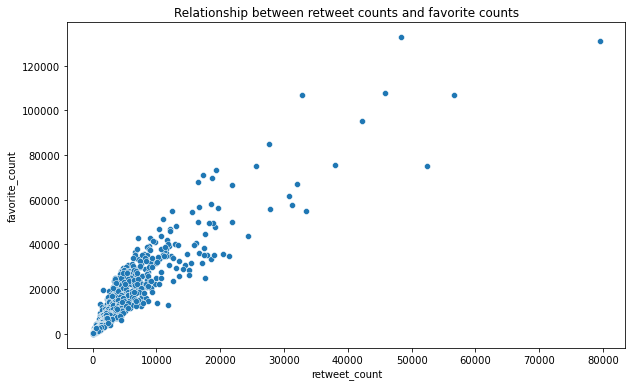

```python
# scatterplot that shows the relationship between retweet and favourite counts of dog breed
plt.figure(figsize=(10,6))
plt.title('Relationship between retweet counts and favorite counts')
sns.scatterplot(x=df['retweet_count'], y=df['favorite_count']);
```

**2. Which source has a high number of retweet counts based on the second prediction of dog breeds?**

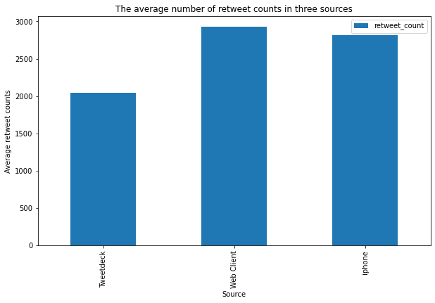

```python
#The bar graph of the average retweet accounts in source.
plt.figure(figsize=(10,6))
df.query('p2_dog==True').groupby('source')['retweet_count'].mean().plot(kind='bar')
plt.title('The average number of retweet counts in three sources')
plt.xlabel("Source")
plt.ylabel("Average retweet counts")
plt.legend();
```

**3. Which level of dog has the highest favorite counts in third dog prediction?**

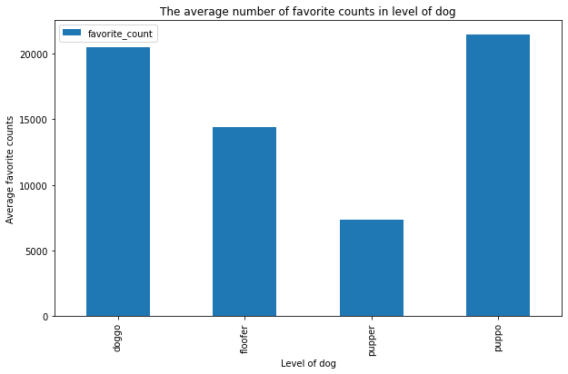

```python
plt.figure(figsize=(10,6))
df.query('p3_dog==True').groupby('dog_level')['favorite_count'].mean().plot(kind='bar')
plt.title('The average number of favorite counts in level of dog')
plt.xlabel("Level of dog")
plt.ylabel("Average favorite counts")
plt.legend();
```

### Visualization

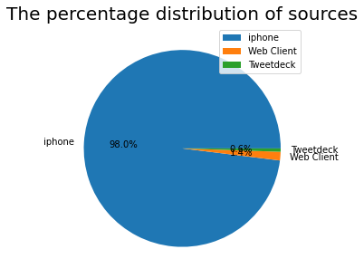

```python
# A pie chart that show the percenatge of the sources.
((df.source.value_counts()/df.source.count())*100).plot.pie(figsize=(10,5),autopct='%2.1f%%')
plt.title('The percentage distribution of sources', {'fontsize':20})
plt.ylabel('')
plt.legend()
plt.show();
```

```python
from subprocess import call
call(['python', '-m', 'nbconvert', 'wrangle_act.ipynb'])
```

```
4294967295
```